# Donga_ard224_assignment7

Rohin Donga

04/17/2023

## Problem 1

#1) As part of the data cleaning process, I extracted the table from the HTML file using the “nodes” feature. The first table in the file contained data for the current day, so I selected it and removed any rows with missing values in the “X” column. Then, I removed all commas and plus signs from the remaining data, replaced any remaining blank cells or NAs with a value of zero, and selected only the columns for country, total cases, new cases, total deaths, and new deaths. I also renamed the “country” column for easier use and converted the last four columns to a numeric data type.

```r
library(tidyverse)
library(rvest)
url <- "https://www.worldometers.info/coronavirus"
covid_tables <- url %>% read_html() %>% html_nodes("table") %>% html_table(fill = TRUE)
covid_today <- as.data.frame(covid_tables[1])
covid_today2 <- covid_today %>% filter(!is.na(X.))
covid_today3 <- covid_today2 %>% mutate_all(funs(str_replace_all(.,",","")))
covid_today4 <- covid_today3 %>% mutate_all(funs(str_replace_all(.,"\\+","")))
covid_today4[covid_today4 == ''] <- 0
covid_today4[is.na(covid_today4)] <- 0
final_df <- covid_today4 %>% select('Country.Other', 'TotalCases', 'NewCases', 'TotalDeaths', 'NewDeaths')
final_df <- rename(final_df, 'Country' = 'Country.Other')
final_df[2:5] <- lapply(final_df[2:5], as.numeric)
```

#2) After obtaining the cleaned dataframe, I extracted only the “country” and “new cases” columns, sorted it in descending order by the “new cases” column, and selected the top 10 entries. Note that this selection is limited to countries where it is already later in the day than the US because I performed this analysis in the morning. Finally, I saved this subset of data to a new dataframe.

```r
top10 <- final_df %>% select('Country','NewCases') %>% arrange(desc(NewCases)) %>% head(10)
top10
```

```
##       Country NewCases
## 1    S. Korea    20197
## 2  Kazakhstan       69
## 3    Pakistan       21
## 4         USA        0
## 5       India        0
## 6      France        0
## 7     Germany        0
## 8      Brazil        0
## 9       Japan        0
## 10      Italy        0
```

#3) To generate a bar chart, I used the ggplot package and applied the reorder function within the aes function to rearrange the x-axis based on a specific variable. I then used the geom_bar function, specifying the “stat” parameter as “identity” to ensure that the height of each bar corresponds to its value in the data. Finally, I customized the plot as needed, including axis labels and other formatting options.

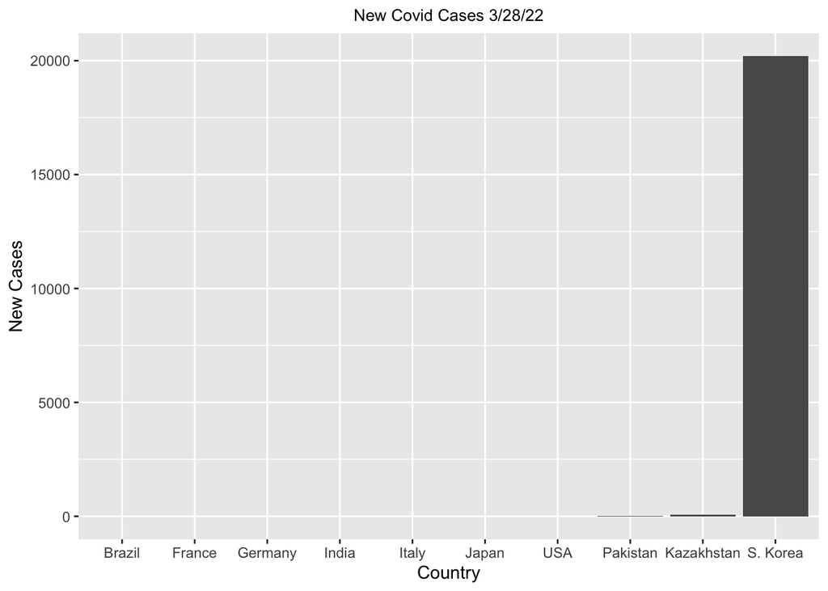

```r
top10 %>% ggplot(aes(reorder(Country, +NewCases), NewCases)) + geom_bar(stat = 'identity') + xlab('Country') + ylab('New Cases') + ggtitle('New Covid Cases 3/28/22') + theme(plot.title = element_text(size = 10)) + theme(plot.title = element_text(hjust = 0.5))
```

## Problem 2

#1)

```r
apikey <- '296ffef85d2d4d05b4dc84455922af0d'
```

```r
library(httr)
library(curl)
library(jsonlite)
url <- "https://api.spoonacular.com/recipes/complexSearch?apiKey=296ffef85d2d4d05b4dc84455922af0d&cuisine=Italian&maxCarbs=30&number=100"
recipe <- url %>% fromJSON()
length(recipe$results$id)
```

```
## [1] 100
```

To extract the recipe IDs and their corresponding carb amounts from the API call, I separated these pieces of information into two different variables. I did this because I needed to use a for loop to create a new column containing the amount of carbs for each recipe. Once I had done this, I combined the two variables into a single dataframe and sorted the results as needed.

```r
recipescol <- as.tibble(recipe$results) %>% select(id, title)
nutrient_list <- recipe$results$nutrition$nutrients
carb_list <- c()
for (i in 1:length(nutrient_list)) {
  carb_list[i] = nutrient_list[[i]]$amount
}
carb_col <- as.tibble(carb_list)
low_carb_df <- bind_cols(recipescol, carb_col)
low_carb_df <- rename(low_carb_df, 'recipe' = 'title', 'carbs' = 'value')
low_carb_df %>% arrange(carbs) %>% head(10)
```

```
## # A tibble: 10 × 3
##        id recipe                                     carbs
##     <int> <chr>                                      <dbl>
##  1 636958 Caprese Sticks                             0.355
##  2 664327 Vanilla Panna Cotta with Chocolate Ganache 0.868
##  3 648715 Kale Bruschetta                            1.46
##  4 658512 Roasted Broccoli                           2.01
##  5 651956 Mini eggplant pizza                        2.13
##  6 648084 Italian Caprese Sliders                    2.22
##  7 642096 Easy Shrimp Scampi                         2.79
##  8 648097 Italian Chicken With Pepper                3.85
##  9 648660 Just Another Tiramisu                      4.04
## 10 664470 Vegan Pea and Mint Pesto Bruschetta        4.14
```

#3) To obtain wine recommendations, I made an API call specifying the search criteria to include only Riesling wines with a maximum price of $50, and to return a maximum of ten results. Once I received the recommended wines from the API, I converted the data into a tibble and selected only the columns for wine ID, title, and price.

```r
url2 <- "https://api.spoonacular.com/food/wine/recommendation?apiKey=296ffef85d2d4d05b4dc84455922af0d&wine=Riesling&maxPrice=50&number=10"
wines <- url2 %>% fromJSON()
rieslings <- as.tibble(wines$recommendedWines) %>% select(id, title, price)
rieslings
```

```
## # A tibble: 10 × 3
##         id title                                                           price
##      <int> <chr>                                                           <chr>
##  1  473052 Schloss Johannisberg Gelblack Riesling                          $34.…
##  2 2043988 Domaine LesSurre Semi Dry Cuvee Classique Riesling              $21.…
##  3  489584 Maximin Grunhauser Herrenberg Riesling Spatlese                 $49.…
##  4  438537 Dr. Hermann Dr. H. Riesling                                     $17.…
##  5  497630 Zilliken Rausch Riesling Spatlese                               $19.…
##  6  433426 Dr. Loosen Dr. L Riesling                                       $10.…
##  7  474522 Bollig-Lehnert Piesporter Goldtroopfchen Riesling Spatlese      $23.…
##  8  437965 J.J. Prum Graacher Himmelreich Kabinett Riesling                $21.…
##  9  430639 NV Amber Falls Winery Sarah's Choice Riesling                   $16.…
## 10  478354 Weingut Darting Durkheimer Nonnengarten Kabinett Riesling (1 L… $18.…
```